# FRTCI: Systematic Variation Estimation Package Tutorial

Ding, P., Feller, A., and Miratrix, L.

2018-01-08

# Introduction

This document demonstrates how to use the systematic variation estimation methods of the `FRTCI` package. First load the package:

```r
library( FRTCI )
```

This package has code to make synthetic data. Here we make a dataset with 3 covariates that we will use to illustrate the function calls. For this dataset, the first two variables have a systematic relationship with treatment impact, and the third is good for adjustment for increasing power:

```r
df = make.randomized.dat( 100, gamma.vec=c(1,1,1,2), beta.vec=c(-1,-1,1) )
str( df )
```

```
## 'data.frame':    100 obs. of  8 variables:
##  $ A   : num  3.04 3.92 3.8 2.99 2.71 ...
##  $ B   : num  1.05 3.1 3.81 3.45 3.57 ...
##  $ C   : num  1.83 3.45 2.24 3.94 3.07 ...
##  $ Y.0 : num  9.63 15.19 11.45 13.98 12.47 ...
##  $ Y.1 : num  6.64 13.36 10.46 13.43 12.33 ...
##  $ tau : num  -2.99 -1.827 -0.989 -0.547 -0.145 ...
##  $ Z   : num  1 0 0 0 0 0 1 1 1 0 ...
##  $ Yobs: num  6.64 15.19 11.45 13.98 12.47 ...
```

## Basic estimation

The function `est.beta` is our core estimator (the naive estimator):

```r
est.beta( Yobs, Z,  ~ A + B, data=df )
```

```
## RI het tx regression (RI-Unadjusted):
##  est.beta(Yobs = Yobs, Z = Z, formula = ~A + B, data = df)
##
## Coefficients:
## (Intercept)            A            B
##      -7.264        4.398       -2.400
##
## Var-Cor Matrix:
##             (Intercept)          A          B
## (Intercept)    82.53149 -13.440683 -15.435057
## A             -13.44068   8.092842  -3.779320
## B             -15.43506  -3.779320   9.621264
##
## Chi-squared test for systematic variation: X^2=2.41 ; p=0.300
##
## Details:  ATE = -0.600 +/- 1.362     SD( Y(0) ) = 3.181   SD( Y(1) ) = 3.712
```

The arguments are observed outcome, observed treatment assignment, and what variables to find a systematic relationship to, expressed as a formula using the tilde notation (categorical covariates will be automatically converted).

The names of the variables don’t matter:

```r
df2 = df[c("A","B","Yobs","Z") ]
names(df2) = c( "AA", "BB", "myY", "myZ" )
rs = est.beta( myY, myZ, myY ~ AA + BB, data=df2 )
rs$beta.hat
```

```
## (Intercept)          AA          BB
##   -7.264251    4.397833   -2.400435
```

We can obtain our standard errors and variance-covariance matrix that comes from the design-based theory:

```r
vcov( rs )
```

```
##             (Intercept)         AA         BB
## (Intercept)    82.53149 -13.440683 -15.435057
## AA            -13.44068   8.092842  -3.779320
## BB            -15.43506  -3.779320   9.621264
```

```r
SE( rs )
```

```
## (Intercept)          AA          BB
##    9.084684    2.844792    3.101816
```

and confidence intervals (using the normal approximation)

```r
confint( rs )
```

```
##                  2.5 %    97.5 %
## (Intercept) -25.069905 10.541403
## AA           -1.177857  9.973523
## BB           -8.479883  3.679013
```

# OLS adjustment

OLS is basically using the emperical covariance matrix Sxx.hat for each treatment arm rather than the known Sxx:

```r
M.ols.ours = est.beta( Yobs, Z, ~ A + B, data=df, method="OLS" )
M.ols.ours
```

```
## RI het tx regression (OLS-Unadjusted):
##  est.beta(Yobs = Yobs, Z = Z, formula = ~A + B, data = df, method = "OLS")
##
## Coefficients:
## (Intercept)            A            B
##     -3.1910      -0.2939       1.1326
##
## Var-Cor Matrix:
##             (Intercept)          A          B
## (Intercept)   1.3446459 -0.1492085 -0.2559752
## A            -0.1492085  0.1701093 -0.1255084
## B            -0.2559752 -0.1255084  0.2184610
##
## Chi-squared test for systematic variation: X^2=7.17 ; p=0.028
##
## Details:  ATE = -0.600 +/- 1.362     SD( Y(0) ) = 3.181   SD( Y(1) ) = 3.712
```

```r
M.ols.ours$beta.hat
```

```
## (Intercept)           A           B
##  -3.1909585  -0.2938507   1.1326091
```

Simple interaction-based OLS approach, to compare with:

```r
M0 = lm( Yobs ~ (A+B) * Z, data=df )
M0
```

```
##
## Call:
## lm(formula = Yobs ~ (A + B) * Z, data = df)
##
## Coefficients:
## (Intercept)            A            B            Z          A:Z
##      3.2907       1.5120       1.5987      -3.1910      -0.2939
##         B:Z
##      1.1326
```

```r
M.ols.ours$beta - coef(M0)[4:6]
```

```
##   (Intercept)             A             B
##  1.407763e-13  5.051515e-15 -1.798561e-14
```

There are no differences up to machine precision.

# Model adjustment

The model-adjusted estimator automatically is used if you give two formula, one for the treatment model, one for the control adjustment model

```r
est.beta( Yobs, Z, ~ A + B, ~ A + B + C, data=df )
```

```
## RI het tx regression (RI-Adjusted):
##  est.beta(Yobs = Yobs, Z = Z, formula = ~A + B, control.formula = ~A +
##      B + C, data = df)
##
## Coefficients:
## (Intercept)            A            B
##      -4.033       -1.002        2.214
##
## Var-Cor Matrix:
##             (Intercept)             A             B
## (Intercept)   12.442674 -2.193183e+00 -1.880863e+00
## A             -2.193183  6.988448e-01  9.888012e-05
## B             -1.880863  9.888012e-05  6.408052e-01
##
## Chi-squared test for systematic variation: X^2=9.08 ; p=0.011
##
## Details:  ATE = -0.600 +/- 1.362     SD( Y(0) ) = 3.181   SD( Y(1) ) = 3.712
```

# Model adjustment + OLS adjustment

using adjustment: we can do with and without emperical Sxx.

```r
est.beta( Yobs, Z,  ~ A + B, ~ A + B + C, data=df )$beta.hat
```

```
## (Intercept)           A           B
##   -4.032674   -1.001657    2.213689
```

```r
est.beta( Yobs, Z,  ~ A + B, ~ A + B + C, data=df, empirical.Sxx = TRUE )$beta.hat
```

```
## (Intercept)           A           B
##   -1.634182   -6.075533    6.539020
```

same as model-adjustment + empirical.Sxx, above

```r
est.beta( Yobs, Z,  ~ A + B, ~ A + B + C, data=df, method="OLS" )$beta.hat
```

```
## (Intercept)           A           B
##   -1.634182   -6.075533    6.539020
```

# Oracle estimator (for simulations and verification of formulae)

If we know all potential outcomes, we can calculate the exact beta for the sample We can also get the true SE, which is why we pass a sample treatment vector (so it can calculate proportion treated, under the assumption of simple random assignment):

```r
Moracle = calc.beta.oracle( Y.1, Y.0,  Z, ~ A + B, data=df )
Moracle
```

```
## RI het tx regression (Oracle RI):
##  calc.beta.oracle(Y1 = Y.1, Y0 = Y.0, Z = Z, formula = ~A + B,
##      data = df)
##
## Coefficients:
## (Intercept)            A            B
##          -1           -1            1
##
## Var-Cor Matrix:
##             (Intercept)          A          B
## (Intercept)    91.05279 -15.152206 -16.689067
## A             -15.15221   9.492788  -4.629426
## B             -16.68907  -4.629426  10.953636
##
## Chi-squared test for systematic variation: X^2=NA ; p=NA
```

```r
SE( Moracle )
```

```
## (Intercept)           A           B
##    9.542158    3.081037    3.309628
```

# When there is no het tx variation

Here we see all the methods on a scenario with no variation

```r
df = make.randomized.dat( 1000, beta.vec=c(-1,0,0) )

calc.beta.oracle( Y.1, Y.0, Z, ~ A + B, data=df )$beta.hat
```

```
##   (Intercept)             A             B
## -1.000000e+00 -2.202682e-13  8.526513e-14
```

```r
est.beta( Yobs, Z, ~ A + B, data=df )$beta.hat
```

```
## (Intercept)           A           B
##   -5.345808    1.159986    0.377972
```

```r
est.beta( Yobs, Z, ~ A + B, data=df, method="OLS" )$beta.hat
```

```
## (Intercept)           A           B
## -0.82985429 -0.02380971 -0.01318476
```

# Looking at R^2

We can look at treatment effect explained. We will look at two scenarios, one with no ideosyncratic variation, and one with a substantial amount. We will plot the R2 sensitivity curves for each on top of each other.

```r
df = make.randomized.dat( 1000, beta.vec=c(-1,1,1) )
rs = est.beta( Yobs, Z, ~ A + B, data=df, method="OLS" )
r2 = R2.ITT( rs )
r2
```

```
## Heterogenous Tx Effect R^2 (ITT)
##  R^2:             0.327 | 0.489 -- 0.998
##
##   Treatment Effect Variances:
##  Systematic:  2.990
##  Ideosyncratic:   0.007 -- 3.123 | 6.162
##  Total:   2.997 -- 6.113 | 9.152
```

```r
plot( r2 )
df = make.randomized.dat( 1000, beta.vec=c(-1,1,1), ideo.sd=3 )
rs = est.beta( Yobs, Z, ~ A + B, data=df, method="OLS" )
r2 = R2.ITT( rs )
r2
```

```
## Heterogenous Tx Effect R^2 (ITT)
##  R^2:             0.141 | 0.214 -- 0.453
##
##   Treatment Effect Variances:
##  Systematic:  3.135
##  Ideosyncratic:   3.780 -- 11.524 | 19.121
##  Total:   6.914 -- 14.659 | 22.256
```

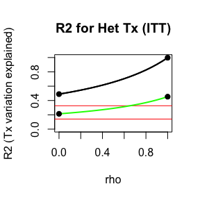

```r
plot( r2, ADD=TRUE, col="green" )
```

And here is a case where we have 100% systematic variation along a single variable.

```r
df = make.randomized.dat( 1000, beta.vec=c(-1,1,0) )
rs = est.beta( Yobs, Z, ~ A + B, data=df, method="OLS" )
r2 = R2.ITT( rs )
r2
```

```
## Heterogenous Tx Effect R^2 (ITT)
##  R^2:             0.114 | 0.202 -- 0.993
##
##   Treatment Effect Variances:
##  Systematic:  0.864
##  Ideosyncratic:   0.006 -- 3.409 | 6.741
##  Total:   0.871 -- 4.273 | 7.605
```

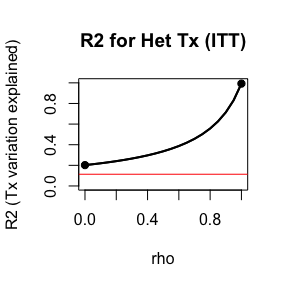

```r
plot( r2 )
```

See, we have 100% R2, if we knew the true individual treatment effects:

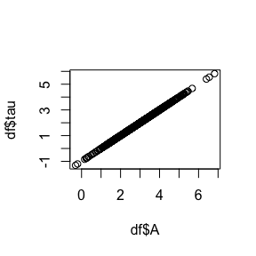

```r
plot( df$tau ~ df$A )
```

## Comparing estimators

Here we look at how results differ across different estimators

```r
df = make.randomized.dat( 1000, beta.vec=c(-1,1,1), ideo.sd=1 )

rs = est.beta( Yobs, Z, ~ A + B, data=df )
r2 = R2.ITT( rs )
r2
```

```
## Heterogenous Tx Effect R^2 (ITT)
##  R^2:             0.113 | 0.203 -- 0.845
##
##   Treatment Effect Variances:
##  Systematic:  1.365
##  Ideosyncratic:   0.250 -- 5.367 | 10.754
##  Total:   1.615 -- 6.732 | 12.119
```

```r
plot( r2, col="green" )

# adjusted
rs = est.beta( Yobs, Z, ~ A + B, ~ A + B, data=df )
r2 = R2.ITT( rs )
r2
```

```
## Heterogenous Tx Effect R^2 (ITT)
##  R^2:             0.385 | 0.551 -- 0.985
##
##   Treatment Effect Variances:
##  Systematic:  5.341
##  Ideosyncratic:   0.079 -- 4.353 | 8.538
##  Total:   5.420 -- 9.694 | 13.879
```

```r
plot( r2, ADD=TRUE )

# adjusted + OLS
rs = est.beta( Yobs, Z, ~ A + B, ~ A + B + C, data=df, empirical.Sxx = TRUE )
r2 = R2.ITT( rs )
r2
```

```
## Heterogenous Tx Effect R^2 (ITT)
##  R^2:             0.528 | 0.690 -- 0.989
##
##   Treatment Effect Variances:
##  Systematic:  13.108
##  Ideosyncratic:   0.141 -- 5.879 | 11.727
##  Total:   13.249 -- 18.988 | 24.835
```

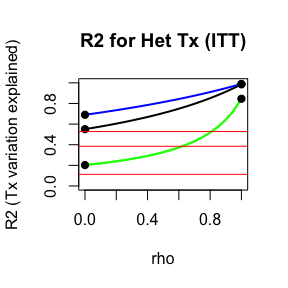

```r
plot( r2, ADD=TRUE, col="blue" )
```

# Testing LATE estimators

Our estimators also work in non-compliance contexts (see paper for details). The story is analogous to the code above.

For this illustration we generate some fake data using a provided function included with the package. It takes a complier treatment heterogeniety model defined by `beta`:

```r
beta = c(-1,6,0)
n = 1000

data = make.randomized.compliance.dat( n, beta.vec=beta )
names(data)
```

```
##  [1] "A"    "B"    "C"    "Y.0"  "Y.1"  "tau"  "Z"    "Yobs" "S"    "D"
```

```r
head( data )
```

```
##          A        B        C      Y.0      Y.1      tau Z     Yobs  S D
## 1 4.007383 2.291615 3.475483 17.26569 40.30999 23.04430 1 40.30999  C 1
## 2 2.585628 2.377510 2.350520 14.42659 28.94036 14.51377 0 14.42659  C 0
## 3 5.398008 4.718647 4.746546 24.57932 24.57932  0.00000 1 24.57932 AT 1
## 4 3.494115 2.876733 2.657843 17.37274 37.33743 19.96469 0 17.37274  C 0
## 5 3.882654 3.611626 3.402797 18.46311 40.75903 22.29593 1 40.75903  C 1
## 6 4.065140 3.600306 2.965285 18.25250 41.64334 23.39084 0 18.25250  C 0
```

```r
zd = with( data, interaction( Z, D, sep="-" ) )
```

Our four observable groups defined by treatment assignment and take-up are as follows:

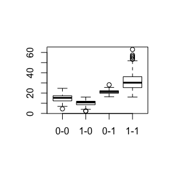

```r
boxplot( Yobs ~ zd, data=data )
```

The true relationships for the three latent groups are as follows:

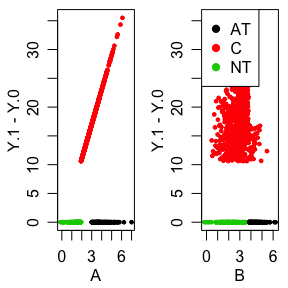

```r
par( mfrow=c(1,2), mgp=c(1.8,0.8,0), mar=c(3,3,0.5,0.5) )
plot( Y.1 - Y.0 ~ A, data=data, col=as.factor(data$S), pch=19, cex=0.5 )
plot( Y.1 - Y.0 ~ B, data=data, col=as.factor(data$S), pch=19, cex=0.5 )
legend( "topleft", legend=levels( as.factor( data$S ) ), pch=19, col=1:3 )
```

(We see no impacts for the AT and the NT as required under the assumptions of noncompliance here.)

## Estimating the effects

```r
rs = est.beta.LATE( Z, D, Yobs, ~ A + B, data=data )
rs
```

```
## RI het tx regression (LATE RI-RI):
##  est.beta.LATE(Z = Z, D = D, Yobs = Yobs, formula = ~A + B, data = data)
##
## Coefficients:
## (Intercept)            A            B
##      10.401        3.282       -1.196
##
## Var-Cor Matrix:
##             (Intercept)        A         B
## (Intercept)   40.777002 -6.79090 -8.213731
## A             -6.790900  1.42374  1.017480
## B             -8.213731  1.01748  2.084543
##
## Chi-squared test for systematic variation: X^2=16.81 ; p=0.000
```

```r
rs$beta.hat
```

```
## (Intercept)           A           B
##   10.400778    3.282122   -1.196270
```

```r
SE( rs )
```

```
## (Intercept)           A           B
##    6.385687    1.193206    1.443795
```

```r
# error
rs$beta.hat - beta
```

```
## (Intercept)           A           B
##   11.400778   -2.717878   -1.196270
```

```r
r2 = R2.LATE( rs )
r2
```

```
## Heterogenous Tx Effect R^2 (LATE)
##  R^2 (within Compliers):      0.141 | 0.174 -- 0.248
##  R^2 for noncompliance alone:     0.657 | 0.702 -- 0.770
##  R^2 for covariates & compliance: 0.705 | 0.754 -- 0.827
##
##   Variances:
##  Systematic Tx Var (Compliers):   6.674
##  Systematic Tx Var (Strata):  63.913
##  Total Systematic Var:        68.641
##  Ideosyncratic Tx Var (Comp):     20.253 -- 31.611 | 40.527
##  Total variation:         82.987 -- 91.032 | 97.347
##
##   Details:   LATE = 17.589   ITT = 12.459    Proportion compliers = 0.708
```

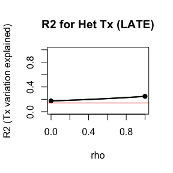

```r
plot( r2 )
```

## The 2SLS Approach

```r
rs = est.beta.LATE( Z, D, Yobs,  ~ A + B, data=data, method="2SLS" )
rs
```

```
## RI het tx regression (LATE RI-2SLS):
##  est.beta.LATE(Z = Z, D = D, Yobs = Yobs, formula = ~A + B, data = data,
##      method = "2SLS")
##
## Coefficients:
## (Intercept)            A            B
##      4.3965       4.6711      -0.5339
##
## Var-Cor Matrix:
##             (Intercept)          A          B
## (Intercept)   24.527380 -4.5422063 -4.1975470
## A             -4.542206  1.1382050  0.4327315
## B             -4.197547  0.4327315  1.1462389
##
## Chi-squared test for systematic variation: X^2=24.60 ; p=0.000
```

```r
SE( rs )
```

```
## (Intercept)           A           B
##    4.952513    1.066867    1.070625
```

```r
rs$beta.hat
```

```
## (Intercept)           A           B
##    4.396489    4.671127   -0.533922
```

```r
rs$beta.hat - beta
```

```
## (Intercept)           A           B
##    5.396489   -1.328873   -0.533922
```